# Give Me Some Credit: Determining the factors which can influence and predict financial credit-based outcomes

Davis George

12/3/2016

# Introduction

## Why is financial credit analysis important?

According to James Grant, author of Money of the Mind: Borrowing and Lending in America from the Civil War to Michael Milken, “It is an axiom nowadays that no bank fails for lack of capital; unprofitable lending is always the underlying cause” (1). Indeed, even when examining the recent ’08 financial crisis, we see that the critical instrument that caused the problem was the proliferation of what was essentially (and simplistically) “bad loans”. Loans are the unit of currency for capital allocation in our economy, they allow capital to flow from savings of those who don’t need to use capital to those who have an ambition to use capital in a way that boosts the economy. Credit analysis is extremely important because it can help us predict where potentially profitable (for both the lender and the economy) loans are and which loans might be less than profitable or even default. Predicting these effects in a systematic way can potentially help avoid financial disasters.

## Our research question and the data that can help answer it:

The data I have is taken from the Kaggle “Give Me Some Credit” competition database, and it’s dimensions are 150,000 observations in 12 variables (2). The research question that I’m trying to answer is whether we can, with some degree of accuracy, predict the probability that a person will experience serious financial difficulty. As is probably obvious, a prediction of this nature could be critical in creating so-called “credit scores” or just generally as a method to assess creditworthiness for a loan. A proxy measure that can answer this question is whether someone experiences 90 days past due delinquencies or worse. This will be the response variable.

My data also includes one ID variable, termed ‘X’ which represents each observation. Finally, there are 10 other potential explanatory variables. For the sake of clarity, I will list them, along with a short definition of what they measure:

1. RevolvingUtilizationOfUnsecuredLines - Total balance on credit cards and personal lines of credit except real estate and no installment debt like car loans, divided by the sum of credit limits.
2. age - Age of borrower in years
3. NumberOfTime30-59DaysPastDueNotWorse - Number of times borrower has been 30-59 days past due but no worse in the last 2 years.
4. DebtRatio - Monthly debt payments, alimony,living costs divided by monthy gross income.
5. MonthlyIncome - Monthly income.
6. NumberOfOpenCreditLinesAndLoans - Number of Open loans (installment like car loan or mortgage) and Lines of credit (e.g. credit cards).
7. NumberOfTimes90DaysLate - Number of times borrower has been 90 days or more past due.
8. NumberRealEstateLoansOrLines - Number of mortgage and real estate loans including home equity lines of credit.
9. NumberOfTime60-89DaysPastDueNotWorse - Number of times borrower has been 60-89 days past due but no worse in the last 2 years.
10. NumberOfDependents - Number of dependents in family excluding themselves (spouse, children etc.).

My specific research hypothesis will be whether the chances of a serious delinquency in 2 years for a given person can be predicted by some combination of the aforementioned predictive variables.

*Please send me an email at davis.george@duke.edu if you’d like to see the full code!*

# Analysis

## Setup

After loading packages, we set the seed so the analysis is consistent, and then load our data. We then split the data into a 75% training, 25% testing dataset.

## Data Cleaning

One serious issue that we encounter when working with any data set is sparsity in datasets (the data might have missing, or “NA” values for certain observations).To find which variables are missing some data; we’ll use a function borrowed from a genetics blog (3).

Proportion Missed - Training

|  | variable | nmiss | n | propmiss |
| --- | --- | --- | --- | --- |
| 1 | X | 0 | 112526 | 0.000 |
| 2 | SeriousDlqin2yrs | 0 | 112526 | 0.000 |
| 3 | RevolvingUtilizationOfUnsecuredLines | 0 | 112526 | 0.000 |
| 4 | age | 0 | 112526 | 0.000 |
| 5 | NumberOfTime30.59DaysPastDueNotWorse | 0 | 112526 | 0.000 |
| 6 | DebtRatio | 0 | 112526 | 0.000 |
| 8 | NumberOfOpenCreditLinesAndLoans | 0 | 112526 | 0.000 |
| 9 | NumberOfTimes90DaysLate | 0 | 112526 | 0.000 |
| 10 | NumberRealEstateLoansOrLines | 0 | 112526 | 0.000 |
| 11 | NumberOfTime60.89DaysPastDueNotWorse | 0 | 112526 | 0.000 |
| 12 | NumberOfDependents | 2937 | 112526 | 0.026 |
| 7 | MonthlyIncome | 22344 | 112526 | 0.199 |

Proportion Missed - Testing

|  | variable | nmiss | n | propmiss |
| --- | --- | --- | --- | --- |
| 1 | X | 0 | 37474 | 0.000 |
| 2 | SeriousDlqin2yrs | 0 | 37474 | 0.000 |
| 3 | RevolvingUtilizationOfUnsecuredLines | 0 | 37474 | 0.000 |
| 4 | age | 0 | 37474 | 0.000 |
| 5 | NumberOfTime30.59DaysPastDueNotWorse | 0 | 37474 | 0.000 |
| 6 | DebtRatio | 0 | 37474 | 0.000 |
| 8 | NumberOfOpenCreditLinesAndLoans | 0 | 37474 | 0.000 |
| 9 | NumberOfTimes90DaysLate | 0 | 37474 | 0.000 |
| 10 | NumberRealEstateLoansOrLines | 0 | 37474 | 0.000 |
| 11 | NumberOfTime60.89DaysPastDueNotWorse | 0 | 37474 | 0.000 |
| 12 | NumberOfDependents | 987 | 37474 | 0.026 |
| 7 | MonthlyIncome | 7387 | 37474 | 0.197 |

For both the training and testing datasets, some of the data for NumberOfDependents and MonthlyIncome is missing. It may be possible to impute these values, but for the sake of simplicity in the analysis, it will be preferable delete those observations (note that we would also normally delete columns that are missing a very high proportion of data, although none of these are) and then note that issue in our caveats section (See Appendix).

Unfortunately, I’m running this analysis on a small Macbook Air, and not an IBM Watson supercomputer. Running analyses with all ~90,000 complete observations results in severe slow down and lagging on this computer. I’ll take a simple random sample from both the training and testing datasets. Dimensions of this simple random sample confirm that our training dataset has 20,000 observations and our testing 5000.

$n_{train} = 20000$

$n_{test} = 5000$

Now, we have a roughly 80%-20% ratio for training vs. testing data, and ~25,000 total observations to work with. One issue is that in both data partitions, our response variable is coded as numeric while it really should be a factor (code not shown).

## Univariate Analysis

Let’s make a cumulative data visualization that shows us each x-variable’s density plot, but seperated by our outcome variable. We would normally also look at contingency tables between the response variable and factored predictive variables, but there are no non-numeric variables in our dataset.

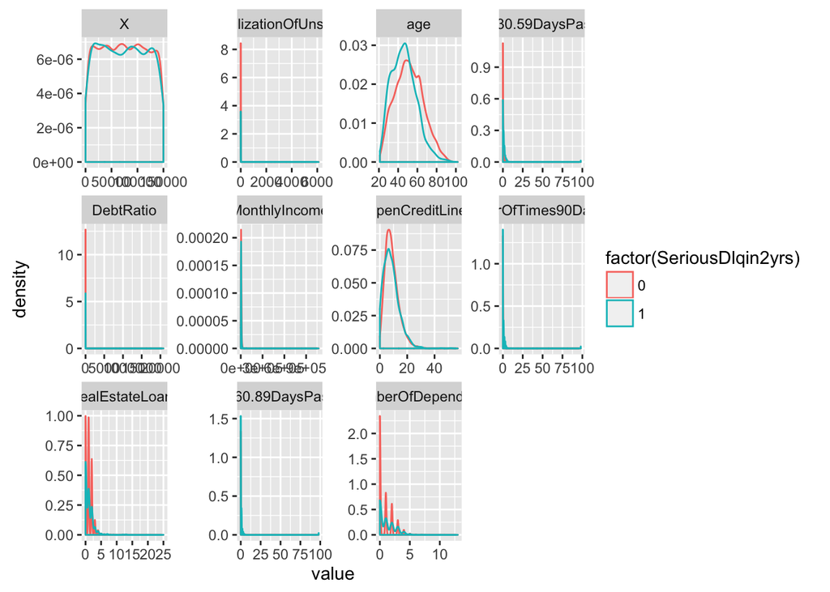

To start, ignore the graph for X, it is an ID variable.

From the graphs, age, NumberOfOpenCreditLinesAndLoans, DebtRatio, and RevolvingUtilizationOfUnsecuredLines all show serious differences between both groups. It seems that those who don’t default are clustered towards older borrowers (age) and towards having a certain peak number of open credit lines (NumberOfOpenCreditLinesAndLoans). For those who don’t default, it seems that they have a lower utilization rate on their credit lines ( RevolvingUtilizationOfUnsecuredLines), as well as a lower debt-to-income ratio (DebtRatio). The other graphs aren’t terribly useful, as they don’t really show the individuals who didn’t default at all. This makes sense as those who were late in the past are also probably the ones who actually defaulted in the dataset.

## Verification of Assumptions, Transformations, and Variable Changes

For a logistic regression, we are primarily concerned with the following assumptions:

1. A large sample size - this is sufficiently satisfied by a total sample size of 25,000 variable, and a training set of 20,000 variables.
2. A linear relationship between the dependent variables and log-odds of response variable - this will best be analyzed in the section which does data validation.
3. No extremely influential outliers. Look for this section later.
4. Low multi-collinearity. Look for this section later.
5. Selection of the correct variables, and those variables have transformed appropriately.

### Variable additions and transformations

We don’t necessarily have to check for homoscedasticity as in logistic regression, but we do want to look at a tentative model and assess whether any transformations are potentially appropriate. Our tentative model simply incudes all predictive variables in a logistic regression.

#### Model 1:

$$Model 1: SeriousDlqin2yrs = RevolvingUtilizationOfUnsecuredLines + age +$$
$$NumberOfTime30.59DaysPastDueNotWorse + DebtRatio + MonthlyIncome +$$
$$NumberOfOpenCreditLinesAndLoans + NumberOfTimes90DaysLate +$$
$$NumberRealEstateLoansOrLines + NumberOfTime60.89DaysPastDueNotWorse + NumberOfDependents, data = df_{samp20000}$$

Model 1 Summary

|  | Estimate | Std. Error | z value | Pr(>\|z\|) |
| --- | --- | --- | --- | --- |
| (Intercept) | -1.523 | 0.112 | -13.561 | 0.000 |
| RevolvingUtilizationOfUnsecuredLines | 0.000 | 0.000 | 0.721 | 0.471 |
| age | -0.024 | 0.002 | -10.496 | 0.000 |
| NumberOfTime30.59DaysPastDueNotWorse | 0.505 | 0.029 | 17.569 | 0.000 |
| DebtRatio | -0.000 | 0.000 | -1.346 | 0.178 |
| MonthlyIncome | -0.000 | 0.000 | -6.599 | 0.000 |
| NumberOfOpenCreditLinesAndLoans | 0.002 | 0.006 | 0.360 | 0.719 |
| NumberOfTimes90DaysLate | 0.495 | 0.043 | 11.399 | 0.000 |
| NumberRealEstateLoansOrLines | 0.072 | 0.028 | 2.557 | 0.011 |
| NumberOfTime60.89DaysPastDueNotWorse | -0.956 | 0.050 | -19.046 | 0.000 |
| NumberOfDependents | 0.143 | 0.023 | 6.282 | 0.000 |

$BIC = 9654.3782206$

Transforming this data with a log could be useful, because it will reduce the scale of these variables and therefore potentially introduce an ability to find significant differences for observations clustered near 0. I add 0.00001 to the values to prevent infinite values for the transformed log variables.

#### Model 1.1:

$$Model 1.1: SeriousDlqin2yrs = log(RevolvingUtilizationOfUnsecuredLines + 0.00001) +$$
$$age + NumberOfTime30.59DaysPastDueNotWorse + log(DebtRatio + 0.00001) +$$
$$MonthlyIncome + NumberOfOpenCreditLinesAndLoans + NumberOfTimes90DaysLate +$$
$$NumberRealEstateLoansOrLines + NumberOfTime60.89DaysPastDueNotWorse +$$
$$NumberOfDependents, data = df_{samp20000}$$

Model 1.1 Summary

|  | Estimate | Std. Error | z value | Pr(>\|z\|) |
| --- | --- | --- | --- | --- |
| (Intercept) | -1.370 | 0.120 | -11.439 | 0.000 |
| log(RevolvingUtilizationOfUnsecuredLines + 1e-05) | 0.344 | 0.020 | 16.771 | 0.000 |
| age | -0.016 | 0.002 | -6.913 | 0.000 |
| NumberOfTime30.59DaysPastDueNotWorse | 0.410 | 0.029 | 14.172 | 0.000 |
| log(DebtRatio + 1e-05) | -0.019 | 0.015 | -1.278 | 0.201 |
| MonthlyIncome | -0.000 | 0.000 | -6.414 | 0.000 |
| NumberOfOpenCreditLinesAndLoans | 0.010 | 0.007 | 1.453 | 0.146 |
| NumberOfTimes90DaysLate | 0.423 | 0.042 | 10.081 | 0.000 |
| NumberRealEstateLoansOrLines | 0.088 | 0.029 | 3.009 | 0.003 |
| NumberOfTime60.89DaysPastDueNotWorse | -0.796 | 0.049 | -16.107 | 0.000 |
| NumberOfDependents | 0.120 | 0.023 | 5.143 | 0.000 |

$BIC = 9208.2734039$

These changes significantly reduce the BIC, and in addition, one of them is highly significant (while the other isn’t). I’m going to keep the significant term and remove the non-significant term.

Furthermore, I think that NumberOfOpenCreditLinesAndLoans could be use a squared term. For instance, if you have 0 lines, it likely means you probably have very bad credit. However, if you have a ton of open lines, it could indicate that you are trying to payoff many lines at once, or take out another credit line to pay off an original debt (an example phenomenon would be when people use credit cards that start with 0 interest, for 6 months, usually, to pay off high interest pay-day loans or the like). Both those with very few credit lines and very many credit lines could be assessed as volatile customers, and the risk of default may go up parabolically, instead of linearly.

Let’s add this to the model.

Note: the squared term I use here is the square of the number of additional credit lines you have open above/below the mean number of credit lines. This helps to avoid collinearity problems later between the linear term and the squared term.

#### Model 2:

$$Model 2: SeriousDlqin2yrs = log(RevolvingUtilizationOfUnsecuredLines + 0.00001)$$
$$+ age + NumberOfTime30.59DaysPastDueNotWorse + DebtRatio + MonthlyIncome +$$
$$NumberOfOpenCreditLinesAndLoans + creditsq + NumberOfTimes90DaysLate +$$
$$NumberRealEstateLoansOrLines + NumberOfTime60.89DaysPastDueNotWorse +$$
$$NumberOfDependents, data = df_samp20000$$

Model 2 Summary

|  | Estimate | Std. Error | z value | Pr(>\|z\|) |
| --- | --- | --- | --- | --- |
| (Intercept) | -1.315 | 0.114 | -11.510 | 0.000 |
| log(RevolvingUtilizationOfUnsecuredLines + 1e-05) | 0.338 | 0.020 | 16.560 | 0.000 |
| age | -0.016 | 0.002 | -6.699 | 0.000 |
| NumberOfTime30.59DaysPastDueNotWorse | 0.415 | 0.029 | 14.324 | 0.000 |
| DebtRatio | -0.000 | 0.000 | -0.944 | 0.345 |
| MonthlyIncome | -0.000 | 0.000 | -6.246 | 0.000 |
| NumberOfOpenCreditLinesAndLoans | -0.003 | 0.007 | -0.397 | 0.692 |
| creditsq | 0.001 | 0.000 | 3.053 | 0.002 |
| NumberOfTimes90DaysLate | 0.414 | 0.042 | 9.843 | 0.000 |
| NumberRealEstateLoansOrLines | 0.085 | 0.028 | 3.074 | 0.002 |
| NumberOfTime60.89DaysPastDueNotWorse | -0.793 | 0.049 | -16.052 | 0.000 |
| NumberOfDependents | 0.121 | 0.023 | 5.209 | 0.000 |

$BIC = 9210.6982147$

In addition, I think number of dependents could use an interaction term between debt-to-income ratio (e.g., if you have more dependents, you could have a higher debt to income ratio, but those debts may be due to say, taking out loans to help finance your child’s education)

#### Model 3:

$$Model 3: SeriousDlqin2yrs = log(RevolvingUtilizationOfUnsecuredLines + 0.00001)$$
$$+ age + NumberOfTime30.59DaysPastDueNotWorse + DebtRatio + MonthlyIncome +$$
$$NumberOfOpenCreditLinesAndLoans + creditsq + NumberOfTimes90DaysLate +$$
$$NumberRealEstateLoansOrLines + NumberOfTime60.89DaysPastDueNotWorse +$$
$$NumberOfDependents + DebtRatio * NumberOfDependents, data = df_{samp20000}$$

Model 3 Summary

|  | Estimate | Std. Error | z value | Pr(>\|z\|) |
| --- | --- | --- | --- | --- |
| (Intercept) | -1.307 | 0.114 | -11.442 | 0.000 |
| log(RevolvingUtilizationOfUnsecuredLines + 1e-05) | 0.338 | 0.020 | 16.573 | 0.000 |
| age | -0.016 | 0.002 | -6.762 | 0.000 |
| NumberOfTime30.59DaysPastDueNotWorse | 0.416 | 0.029 | 14.341 | 0.000 |
| DebtRatio | 0.000 | 0.000 | 1.608 | 0.108 |
| MonthlyIncome | -0.000 | 0.000 | -6.405 | 0.000 |
| NumberOfOpenCreditLinesAndLoans | -0.003 | 0.007 | -0.381 | 0.703 |
| creditsq | 0.001 | 0.000 | 3.025 | 0.002 |
| NumberOfTimes90DaysLate | 0.411 | 0.042 | 9.843 | 0.000 |
| NumberRealEstateLoansOrLines | 0.087 | 0.028 | 3.142 | 0.002 |
| NumberOfTime60.89DaysPastDueNotWorse | -0.791 | 0.049 | -16.096 | 0.000 |
| NumberOfDependents | 0.128 | 0.023 | 5.515 | 0.000 |
| DebtRatio:NumberOfDependents | -0.000 | 0.000 | -2.552 | 0.011 |

$BIC = 9207.607878$

This interaction term appears to be significant.

To confirm, we can utilze a drop-in-deviance test between model 2, and model 3, to assess whether the additional deviance explained by model 3 is significant.

Anova Summary for GLM-2 vs. GLM-3

|  | Resid. Df | Resid. Dev | Df | Deviance | Pr(>Chi) |
| --- | --- | --- | --- | --- | --- |
| 1 | 19988.000 | 9091.856 |  |  |  |
| 2 | 19987.000 | 9078.863 | 1.000 | 12.994 | 0.000 |

A drop-in-deviance test confirms what we saw earlier, that adding the interaction term definitely does significantly change the predictive capability of the model.

At this point, I don’t think many parts of the data other than these two show a serious case for interaction terms or squared terms. We will continue using glm3.

### Outlier analysis

To assess outliers, I made a graph of Cook’s distance for our model 3.

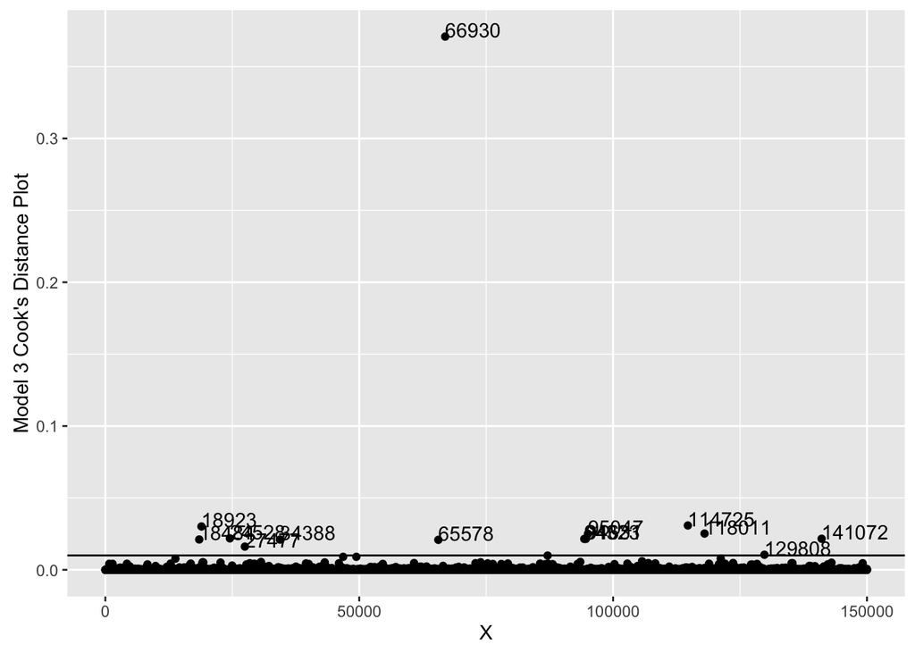

At this point, we see that there are several points which are heavily seperated from the rest of the dataset. I used cutoff of about 0.01 to be removed. Note that the standard cutoff for removing outliers would be 4/n, where n is the sample size, which is 2e-04 in this case for n = 20,000. This cutoff would remove about 1400 observations, a significant part (>5%) of our dataset. I believe a more appropriate cutoff is 0.01, enough to remove all of the observations that show out of the ordinary explanatory values, but without compromising the integrity of our dataset (only removes ~15 observations, or ~0.1% of our dataset).

$n = 19986$

In the dataset, after I removed outliers from the dataset that had “large” gaps from the rest of the data in terms of cook’s distance, there were about 19986 observations still remaining.

We’ll now make another model that is the same as our model 3 in terms of variables, but uses a modified dataset with outliers removed.

#### Model 4:

$$Model 4: SeriousDlqin2yrs = log(RevolvingUtilizationOfUnsecuredLines + 0.00001)$$
$$+ age + NumberOfTime30.59DaysPastDueNotWorse + DebtRatio + MonthlyIncome +$$
$$NumberOfOpenCreditLinesAndLoans + creditsq + NumberOfTimes90DaysLate +$$
$$NumberRealEstateLoansOrLines + NumberOfTime60.89DaysPastDueNotWorse +$$
$$NumberOfDependents + DebtRatio * NumberOfDependents, data = df_{samp20000_rmv}$$

Model 4 Summary

|  | Estimate | Std. Error | z value | Pr(>\|z\|) |
| --- | --- | --- | --- | --- |
| (Intercept) | -1.644 | 0.123 | -13.372 | 0.000 |
| log(RevolvingUtilizationOfUnsecuredLines + 1e-05) | 0.255 | 0.019 | 13.122 | 0.000 |
| age | -0.018 | 0.003 | -7.094 | 0.000 |
| NumberOfTime30.59DaysPastDueNotWorse | 0.489 | 0.029 | 16.839 | 0.000 |
| DebtRatio | -0.001 | 0.001 | -2.143 | 0.032 |
| MonthlyIncome | -0.000 | 0.000 | -7.175 | 0.000 |
| NumberOfOpenCreditLinesAndLoans | 0.007 | 0.008 | 0.964 | 0.335 |
| creditsq | 0.001 | 0.000 | 2.583 | 0.010 |
| NumberOfTimes90DaysLate | 0.826 | 0.048 | 17.130 | 0.000 |
| NumberRealEstateLoansOrLines | 0.133 | 0.028 | 4.722 | 0.000 |
| NumberOfTime60.89DaysPastDueNotWorse | 0.513 | 0.059 | 8.627 | 0.000 |
| NumberOfDependents | 0.086 | 0.025 | 3.449 | 0.001 |
| DebtRatio:NumberOfDependents | 0.000 | 0.000 | 0.177 | 0.859 |

$BIC = 8328.1686652$

Removing these observations has a remarkable effect. The $BIC = 8328.1686652$ is lowered by about ~1000, an orders of magnitude greater reduction than any changes in variable term above. In addition, only NumberOfOpenCreditLinesAndLoans, and surprisingly, the intearaction term from earlier, aren’t significant in this model.

### Multi-Collinearity

To test multi-collinearity, we will first look at a plot of the correlation matrix of all of the explanatory variables. We will also test the variance inflation factor for each variable.

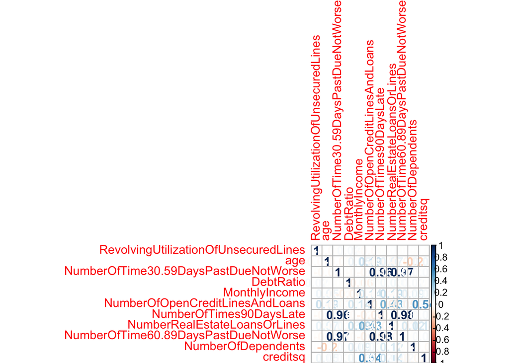

VIF Table for GLM-4

| log(RevolvingUtilizationOfUnsecuredLines + 1e-05) | 1.0995 |
| --- | --- |
| age | 1.1564 |
| NumberOfTime30.59DaysPastDueNotWorse | 1.1334 |
| DebtRatio | 2.3316 |
| MonthlyIncome | 1.3362 |
| NumberOfOpenCreditLinesAndLoans | 2.1229 |
| creditsq | 1.5384 |
| NumberOfTimes90DaysLate | 1.1280 |
| NumberRealEstateLoansOrLines | 1.4408 |
| NumberOfTime60.89DaysPastDueNotWorse | 1.1265 |
| NumberOfDependents | 1.0678 |
| DebtRatio:NumberOfDependents | 2.3286 |

The correlation plot shows that all of the “late” variables, (NumberOfTime30.59DaysPastDueNotWorse, etc.) are very highly correlated. No other correlations are serious (greater than about 0.7). When we look at the variance inflation factors, however, none of these variables (or any of the other variables included in the model prove to highly inflate the variance in the model, meaning that there is a relatively low likelihood that these variables are causing each other to be insignificant or obscuring causative effects).

For good measure, I’ve combined the late variables into one, weighted, late variable, and created a model.

#### Model 6:

$$Model 6: SeriousDlqin2yrs = log(RevolvingUtilizationOfUnsecuredLines + 0.00001)$$
$$+ age + late + DebtRatio + MonthlyIncome+ creditsq + NumberRealEstateLoansOrLines$$
$$+ NumberOfDependents, data = df_{samp20000_rmv}$$

Model 6 Summary

|  | Estimate | Std. Error | z value | Pr(>\|z\|) |
| --- | --- | --- | --- | --- |
| (Intercept) | -1.958 | 0.124 | -15.793 | 0.000 |
| log(RevolvingUtilizationOfUnsecuredLines + 1e-05) | 0.260 | 0.019 | 13.447 | 0.000 |
| age | -0.016 | 0.002 | -6.727 | 0.000 |
| late | 0.318 | 0.011 | 29.282 | 0.000 |
| DebtRatio | -0.001 | 0.000 | -2.959 | 0.003 |
| MonthlyIncome | -0.000 | 0.000 | -7.058 | 0.000 |
| creditsq | 0.001 | 0.000 | 3.717 | 0.000 |
| NumberRealEstateLoansOrLines | 0.156 | 0.026 | 6.021 | 0.000 |
| NumberOfDependents | 0.089 | 0.025 | 3.594 | 0.000 |

$BIC = 8333.4028408$

VIF Table for GLM-6

| log(RevolvingUtilizationOfUnsecuredLines + 1e-05) | 1.0863 |
| --- | --- |
| age | 1.1089 |
| late | 1.0586 |
| DebtRatio | 1.0106 |
| MonthlyIncome | 1.3048 |
| creditsq | 1.0412 |
| NumberRealEstateLoansOrLines | 1.2851 |
| NumberOfDependents | 1.0616 |

In some sense, we’ve come to kind of a head. Our model 6 reduces multi-collinearity in a good way, but our model 4 has very significant predictors and a better BIC (but has some extremely collinear variables).

A great explanation for this effect (VIF is low, correlation matrix shows high correlations) is how the 3 “late” variables are coded, in terms of number of times a payment is late (within a certain time period) instead of if a payment is late (within a certain time period). This means that although there is likely to be a documented really strong correlation that when one variable increases, the other increases, the actual prediction value for that may not get any better. This is due to the number of times a payment being late basically divided into independent “buckets”, instead of accumulating the total number of times a payment is late. For instance, if someone is late once during the 0-30 day period, a regression on NumberOfTimes90DaysLate vs. NumberOfTime30.59DaysPastDueNotWorse might predict 1.5, while the actual number of times someone is greater than 90 days late is 3. This is a large error in number of times late during each independent period that isn’t accounted for a weighted late variable.

We can run another drop-in-deviance test to see whether either model significantly reduces the deviance in our dataset.

Anova Summary for GLM-6 vs. GLM-4

|  | Resid. Df | Resid. Dev | Df | Deviance | Pr(>Chi) |
| --- | --- | --- | --- | --- | --- |
| 1 | 19977.000 | 8244.278 |  |  |  |
| 2 | 19973.000 | 8199.432 | 4.000 | 44.845 | 0.000 |

In this case, although the model 6 reduced multi-collinearity, model 4 has an extremely significant difference in deviance reduction (in other words, model 4 has significantly lower deviance), there is less 5% chance that the differences between these two models occured by chance, and as such, we will continue with our model 4 for our final selection procedure (besides, the variance inflation associated with the collinear variables was well under the cutoff for concern).

Essentially, what this means is that the variables might be highly correlated, but the variation (R^2) explained by the model fit on these variables is fairly low. This means that the 3 variables, although they seem to be highly multi-collinear, aren’t increasing the variance significantly for the model because they are all adding new information.

## Final Selection

We utilize the BMA (Bayesian Model Averaging) Package to determine the posterior probabilities for 5 top models in terms of which variables are included in the model, on the model 4 we previously estimated.

This method looks at k potential models (by adding or dropping explanatory variables), then it calculates the BIC and transforms it to be positive, e.g., so that a lower BIC is associated with a higher probability of being in the model. It then multiplies that by the prior probability of getting a Model k (which would be 1/k for k potential models) to get the posterior probability for model k. It then divides each posterior probability by the sum of the posterior probabilities for the other model to get the percentage chance that this model is the true model, given the data.

From my understanding, this is analogous to the method explained in the Ramsey & Shafer book, on page 366 (4).

The practical benefit of this technique are two-fold. First, we get to see a number of potential models, given an input model, and the posterior probability that this is the true model (scaled by BIC value). Second, we can performed model-averaging to determine a model that incorporates some aspect of all of the various potential models. I find that this method is preferable to stepAIC, or selection just by BIC criterion, because it allows us to allocate weight to a lower BIC, but not arbitrarily eliminate models that have higher ones.

Note: increasing OR increases the number of models considered, it is the Occam’s Razor window, basically looks at number of models needed for parsimony.

We’ll create another logistic model representing the most likely model from BMA.

#### Model 4.1:

$$Model 4.1: SeriousDlqin2yrs = log(RevolvingUtilizationOfUnsecuredLines + 0.00001)$$
$$+ age + NumberOfTime30.59DaysPastDueNotWorse + NumberOfTime60.89DaysPastDueNotWorse$$
$$+ NumberOfTimes90DaysLate + MonthlyIncome + DebtRatio +$$
$$NumberRealEstateLoansOrLines + NumberOfDependents, data = df_{samp20000_rmv}$$

Model 4.1 Summary

|  | Estimate | Std. Error | z value | Pr(>\|z\|) |
| --- | --- | --- | --- | --- |
| (Intercept) | -1.613 | 0.122 | -13.227 | 0.000 |
| log(RevolvingUtilizationOfUnsecuredLines + 1e-05) | 0.254 | 0.019 | 13.202 | 0.000 |
| age | -0.017 | 0.002 | -6.996 | 0.000 |
| NumberOfTime30.59DaysPastDueNotWorse | 0.492 | 0.029 | 17.169 | 0.000 |
| NumberOfTime60.89DaysPastDueNotWorse | 0.510 | 0.059 | 8.597 | 0.000 |
| NumberOfTimes90DaysLate | 0.822 | 0.047 | 17.335 | 0.000 |
| MonthlyIncome | -0.000 | 0.000 | -7.039 | 0.000 |
| DebtRatio | -0.001 | 0.000 | -3.055 | 0.002 |
| NumberRealEstateLoansOrLines | 0.155 | 0.027 | 5.847 | 0.000 |
| NumberOfDependents | 0.082 | 0.025 | 3.326 | 0.001 |

All of the variables in this model are highly significant, at either a ‘0’ level, or a ‘0.001’ level.

A model can also be created to represent the average of the top 5 models from the BMA package:

#### Model 4.AVG:

$$Model 4.avg: SeriousDlqin2yrs = log(RevolvingUtilizationOfUnsecuredLines + 0.00001)$$
$$+ age + NumberOfTime30.59DaysPastDueNotWorse + NumberOfTime60.89DaysPastDueNotWorse$$
$$+ NumberOfTimes90DaysLate + MonthlyIncome + DebtRatio +$$
$$NumberRealEstateLoansOrLines + NumberOfDependents, data = df_{samp20000_rmv}$$

Keep in mind that although this model looks functionally the same as Model 4.1, the model has different coefficients that represent the averaged out values from the BMA analysis.

Coefficients for BMA Average Model

| (Intercept) | -1.5925 |
| --- | --- |
| log(RevolvingUtilizationOfUnsecuredLines + 1e-05) | 0.2546 |
| age | -0.0177 |
| NumberOfTime30.59DaysPastDueNotWorse | 0.4938 |
| NumberOfTime60.89DaysPastDueNotWorse | 0.5140 |
| NumberOfTimes90DaysLate | 0.8220 |
| DebtRatio | -0.0010 |
| MonthlyIncome | -0.0001 |
| NumberOfOpenCreditLinesAndLoans | 0.0010 |
| creditsq | 0.0008 |
| NumberRealEstateLoansOrLines | 0.1463 |
| NumberOfDependents | 0.0576 |

# Data Validation - Prediction and RoC curves

## Predict for highest probability model

We’ll use our model from the Final Selection analysis section to predict values for our testing dataset.

$$Model 4.1: SeriousDlqin2yrs = log(RevolvingUtilizationOfUnsecuredLines + 0.00001) +$$
$$age + NumberOfTime30.59DaysPastDueNotWorse + NumberOfTime60.89DaysPastDueNotWorse +$$
$$NumberOfTimes90DaysLate + MonthlyIncome + DebtRatio +$$
$$NumberRealEstateLoansOrLines + NumberOfDependents, data = df_{samp20000_rmv}$$

Note: When we predict from model 4.1, we are predicting log-odds (logit), and we need to convert those logits to probabilities to compare with the 0/1 values in our testing dataset.

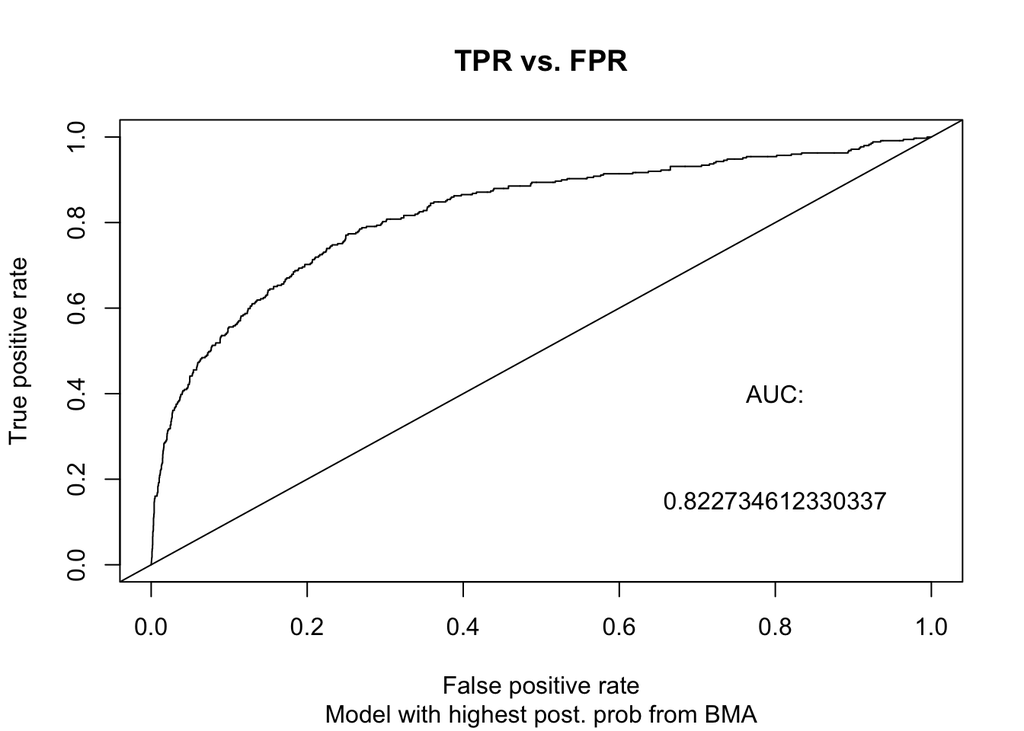

## Predict for Bayesian Model Average

We can also use the averaged model (of the top 5 models selected above) to predict on the testing dataset. This comes directly from the BMA model selection function.

$$Model 4.avg: SeriousDlqin2yrs = log(RevolvingUtilizationOfUnsecuredLines + 0.00001)$$
$$+ age + NumberOfTime30.59DaysPastDueNotWorse + NumberOfTime60.89DaysPastDueNotWorse$$
$$+ NumberOfTimes90DaysLate + MonthlyIncome + DebtRatio +$$
$$NumberRealEstateLoansOrLines + NumberOfDependents, data = df_{samp20000_rmv}$$

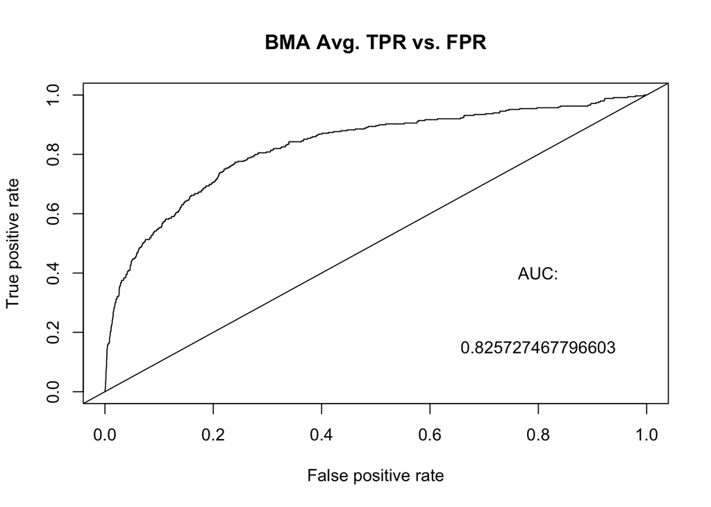

## Making sure to test our highest post. prob model on the actual data.

This step is extremely important, as it allows us to assess whether some of the significance of the variables in the above two models is due to overfitting, and helps us understand if have really created the best model for any dataset of the original predictive variables.

#### Model 4.1.t:

$$Model 4.1.test: SeriousDlqin2yrs = log(RevolvingUtilizationOfUnsecuredLines + 0.00001)$$
$$+ age + NumberOfTime30.59DaysPastDueNotWorse + NumberOfTime60.89DaysPastDueNotWorse$$
$$+ NumberOfTimes90DaysLate + MonthlyIncome + DebtRatio +$$
$$NumberRealEstateLoansOrLines + NumberOfDependents, data = df_{samp20000_rmv}$$

Model 4.1 Summary - Test

|  | Estimate | Std. Error | z value | Pr(>\|z\|) |
| --- | --- | --- | --- | --- |
| (Intercept) | -1.390 | 0.229 | -6.077 | 0.000 |
| log(RevolvingUtilizationOfUnsecuredLines + 1e-05) | 0.244 | 0.034 | 7.153 | 0.000 |
| age | -0.016 | 0.005 | -3.446 | 0.001 |
| NumberOfTime30.59DaysPastDueNotWorse | 0.448 | 0.058 | 7.677 | 0.000 |
| NumberOfTime60.89DaysPastDueNotWorse | -0.873 | 0.095 | -9.150 | 0.000 |
| NumberOfTimes90DaysLate | 0.455 | 0.082 | 5.549 | 0.000 |
| MonthlyIncome | -0.000 | 0.000 | -2.727 | 0.006 |
| DebtRatio | -0.000 | 0.000 | -0.928 | 0.353 |
| NumberRealEstateLoansOrLines | 0.014 | 0.061 | 0.222 | 0.824 |
| NumberOfDependents | 0.051 | 0.046 | 1.114 | 0.265 |

Indeed, fitting the model on the testing data reveals that only a subsection of the data is actually still significant. I believe that this may be due to overfitting of the model on the data, to some extent (overfitting isn’t a huge concern with an n = 20,000 observations which is >> k = 8 parameters).

When considering which models may predict this real world data best, it may be ideal to make a model without the variables considered not significant. (This model will be interpreted in the Conclusion section).

#### Model 4.2.t:

$$Model 4.2.test: SeriousDlqin2yrs = log(RevolvingUtilizationOfUnsecuredLines + 0.00001)$$
$$+ age + NumberOfTime30.59DaysPastDueNotWorse + NumberOfTime60.89DaysPastDueNotWorse$$
$$+ NumberOfTimes90DaysLate + MonthlyIncome, data = df_{samp20000_rmv}$$

This model removes DebtRatio, NumberRealEstateLoansOrLines, and NumberOfDependents.

# Discussion & Conclusion

## RoC Curves and AURoC

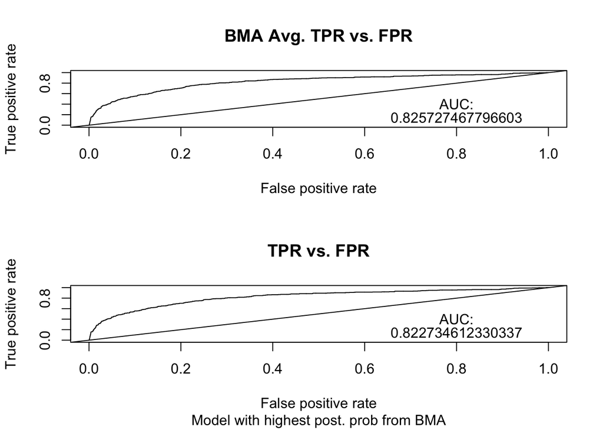

A RoC Curve plots sensitivity (the true positive rate) vs. specificity (the false positive rate). The closer that the the RoC curve gets to the upper left corner of the graph, the better the model is for predicting values (as touching the upper left corner would indicate that 100% of the predicted true were actually true, and therefore 100% of the predicted false were actually false).

The area under the curve measures discrimination, that is, the ability of the model to correctly classify those who do or don’t have delinquencies. Consider the situation in which potential loanees are already correctly classified into two groups. You randomly pick on from the default group and one from the no-default group and run the model on both. The person with the greater probability of default according to the model should be the person in the default group. The area under the curve is the percentage of randomly drawn pairs for which this is true (that is, the test correctly classifies the two patients in the random pair).

In the end, our models both show decent RoC curves, and the area under the curves are >0.8, which indicates that these models are fairly good discriminators in our test data.

Although the RoC curves presented above somewhat validate our model on the testing data, I wanted to be sure and create a new model with only the variables that were significant when running model 4.1 on the testing data.

Obviously, it would also be possible to take this model, plug it into the BMA package, and average out the models by using posterior probabilities as weights. Then to run that model on another testing data set, and repeat the process again. However, we have already moved a bit past the scope of the class when validating data.

## Conclusive Models

To conclude, I present this model as the model, from the original predictor variables, that can be said to best predict the probability of delinquency in the next 90 days for individuals in the dataset, even when accounting for a seperate testing data-set.

$$Model 4.2.test: SeriousDlqin2yrs = log(RevolvingUtilizationOfUnsecuredLines + 0.00001)$$
$$+ age + NumberOfTime30.59DaysPastDueNotWorse + NumberOfTime60.89DaysPastDueNotWorse$$
$$+ NumberOfTimes90DaysLate + MonthlyIncome, data = df_{samp20000_rmv}$$

Model 4.2 Summary - Test

|  | Estimate | Std. Error | z value | Pr(>\|z\|) |
| --- | --- | --- | --- | --- |
| (Intercept) | -1.344 | 0.220 | -6.120 | 0.000 |
| log(RevolvingUtilizationOfUnsecuredLines + 1e-05) | 0.246 | 0.034 | 7.221 | 0.000 |
| age | -0.016 | 0.004 | -3.685 | 0.000 |
| NumberOfTime30.59DaysPastDueNotWorse | 0.452 | 0.058 | 7.763 | 0.000 |
| NumberOfTime60.89DaysPastDueNotWorse | -0.885 | 0.095 | -9.297 | 0.000 |
| NumberOfTimes90DaysLate | 0.463 | 0.082 | 5.676 | 0.000 |
| MonthlyIncome | -0.000 | 0.000 | -2.603 | 0.009 |

Exponentiated Coefficients

| (Intercept) | 0.2608 |
| --- | --- |
| log(RevolvingUtilizationOfUnsecuredLines + 1e-05) | 1.2790 |
| age | 0.9838 |
| NumberOfTime30.59DaysPastDueNotWorse | 1.5714 |
| NumberOfTime60.89DaysPastDueNotWorse | 0.4128 |
| NumberOfTimes90DaysLate | 1.5883 |
| MonthlyIncome | 1.0000 |

Based on the RoC Curves, the two models taken from the BMA analysis (and not modified after being tested on the testing data, which is a distinct advantage) are also quite useful for predicting the probability of default

$$Model 4.1.test: SeriousDlqin2yrs = log(RevolvingUtilizationOfUnsecuredLines + 0.00001)$$
$$+ age + NumberOfTime30.59DaysPastDueNotWorse + NumberOfTime60.89DaysPastDueNotWorse$$
$$+ NumberOfTimes90DaysLate + MonthlyIncome + DebtRatio +$$
$$NumberRealEstateLoansOrLines + NumberOfDependents, data = df_{samp20000_rmv}$$

$$Model 4.avg: SeriousDlqin2yrs = log(RevolvingUtilizationOfUnsecuredLines + 0.00001)$$
$$+ age + NumberOfTime30.59DaysPastDueNotWorse + NumberOfTime60.89DaysPastDueNotWorse$$
$$+ NumberOfTimes90DaysLate + MonthlyIncome + DebtRatio + NumberRealEstateLoansOrLines$$
$$+ NumberOfDependents, data = df_{samp20000_rmv}$$

## Interpreting the Model

It’s important to put the coefficients and exponentiated coeffecients from the model (Model 4.2.test) in context. A coefficient for a variable from the summary for our final model is considered significant if it’s p-value is less than 0.05, which is a p-value for the t-test that the coefficient is 0 (or equivalently, for any variable the probability that you would get observations as extreme as those observed in the variable if the null hypothesis that the coefficient was 0 was true). In essence, the significance of coefficients in the model relates to whether they actually have predictive power.

In addition, we must be able to interpret the coefficients from our final model in the context of our research question. Let’s take one exponentiated coefficient, the coefficient for age, which is 0.9837940. Consider the hypothetical scenario where the standard odds of defaulting are 1:4, meaning that there are 1 defaults for every 4 non-default. A one-unit increase in the age of a potential loanee decreases these odds, 1/4, by a factor of ~0.98, to 0.98:4, meaning there are now 0.98 defaults for every 4 non-defaults.

In addition to odds ratios, this model can also be used to essentially predict the probability of default for a vector filled with values of each of the explanatory variables (for a single case or observation):

Let’s look at what this would look like for the case for predict the probability of default at the mean of each explanatory variable:

$$logit_{mean} = -1.3440789416 + -0.0163387389 * mean(age)$$
$$+ 0.2460560017 * mean(log(RevolvingUtilizationOfUnsecuredLines)) + ... +$$
$$0.4626490173 * mean(NumberOfTimes90DaysLate)$$

$p_{default} = exp(logit(mean)) / (1 + exp(logit(mean))) = 0.0891$

## Caveats

1. I have a smaller computer, which therefore requires we take smaller simple random samples instead of analyzing, say 80% of the full 150,000 observation dataset.
2. We deleted cases that were incomplete. Ideally, you’d use imputation to fill in these data points. This requires more advanced statsitics.
3. I had to restart my data project right about after the third draft. The original loans dataset I was using, which predicted the percent recovered on a loan using linear regression, had an R-Square of 0.019. While this might not normally be a reason by itself to drop the dataset, I discovered that the company that published the data had taken out roughly 50% of the explanatory variables in 2014 (although this wasn’t listed on the website). As such, I knew this data would not represent any question of interest of value. I did put quite a bit of work into my first two drafts for this previous dataset, especially with data cleaning / basic testing / univariate data analysis, and would really appreciate if you’d be able to take a look at the other .rmd file (LendingClub) I’ve included in my submission.
4. I don’t believe that the predictive variables in my dataset encompass all of the possible values that can predict someone’s probability of default. One variable that could be missing would be the overall FICO credit score, another could be whether the person completed college. It’s more accurate to conclude that of the predictive variables given, these variables (from model 4.2.test) give the most predictive accuracy on a random sample of testing data.

## Sources

1. http://www.fool.com/investing/general/2015/02/04/my-50-favorite-quotes-about-banking.aspx
2. https://www.kaggle.com/c/GiveMeSomeCredit
3. http://www.gettinggeneticsdone.com/2011/02/summarize-missing-data-for-all.html
4. The Statistical Sleuth: A Course in Methods of Data Analysis, Third Edition Fred L. Ramsey, Daniel W. Schafer

# Shiny App

I created an interactive app which uses the last model included in my analysis to predict and return the probability of default for given parameters.

It can be viewed at: https://dgeorge668.shinyapps.io/Credit-Prediction/